# Biostat 212a Homework 6

Due Mar 22, 2024 @ 11:59PM

Author

Chengwu Duan and 606332825

Published

March 22, 2024

Load R libraries.

```r
rm(list = ls())
library(tidyverse)
library(tidymodels)
library(readr)
library(tswge)
library(ggplot2)
library(yardstick)
library(workflows)
library(parsnip)
library(tidyclust)
library(RcppHungarian)

acfdf <- function(vec) {
    vacf <- acf(vec, plot = F)
    with(vacf, data.frame(lag, acf))
}

ggacf <- function(vec) {
    ac <- acfdf(vec)
    ggplot(data = ac, aes(x = lag, y = acf)) + geom_hline(aes(yintercept = 0)) +
        geom_segment(mapping = aes(xend = lag, yend = 0))
}

tplot <- function(vec) {
    df <- data.frame(X = vec, t = seq_along(vec))
    ggplot(data = df, aes(x = t, y = X)) + geom_line()
}
```

## 1 New York Stock Exchange (NYSE) data (1962-1986) (140 pts)

[figure not shown]

Figure 1: Historical trading statistics from the New York Stock Exchange. Daily values of the normalized log trading volume, DJIA return, and log volatility are shown for a 24-year period from 1962-1986. We wish to predict trading volume on any day, given the history on all earlier days. To the left of the red bar (January 2, 1980) is training data, and to the right test data.

The [`NYSE.csv`](https://raw.githubusercontent.com/ucla-biostat-212a/2024winter/master/slides/data/NYSE.csv) file contains three daily time series from the New York Stock Exchange (NYSE) for the period Dec 3, 1962-Dec 31, 1986 (6,051 trading days).

- `Log trading volume` ($v_t$): This is the fraction of all outstanding shares that are traded on that day, relative to a 100-day moving average of past turnover, on the log scale.
- `Dow Jones return` ($r_t$): This is the difference between the log of the Dow Jones Industrial Index on consecutive trading days.
- `Log volatility` ($z_t$): This is based on the absolute values of daily price movements.

```r
# Read in NYSE data from url

url = "https://raw.githubusercontent.com/ucla-biostat-212a/2024winter/master/slides/data/NYSE.csv"
NYSE <- read_csv(url)

NYSE
```

```
# A tibble: 6,051 × 6
   date       day_of_week DJ_return log_volume log_volatility train
   <date>     <chr>           <dbl>      <dbl>          <dbl> <lgl>
 1 1962-12-03 mon         -0.00446     0.0326           -13.1 TRUE
 2 1962-12-04 tues         0.00781     0.346            -11.7 TRUE
 3 1962-12-05 wed          0.00384     0.525            -11.7 TRUE
 4 1962-12-06 thur        -0.00346     0.210            -11.6 TRUE
 5 1962-12-07 fri          0.000568    0.0442           -11.7 TRUE
 6 1962-12-10 mon         -0.0108      0.133            -10.9 TRUE
 7 1962-12-11 tues         0.000124   -0.0115           -11.0 TRUE
 8 1962-12-12 wed          0.00336     0.00161          -11.0 TRUE
 9 1962-12-13 thur        -0.00330    -0.106            -11.0 TRUE
10 1962-12-14 fri          0.00447    -0.138            -11.0 TRUE
# ℹ 6,041 more rows
```

The **autocorrelation** at lag $\ell$ is the correlation of all pairs $(v_t, v_{t-\ell})$ that are $\ell$ trading days apart. These sizable correlations give us confidence that past values will be helpful in predicting the future.

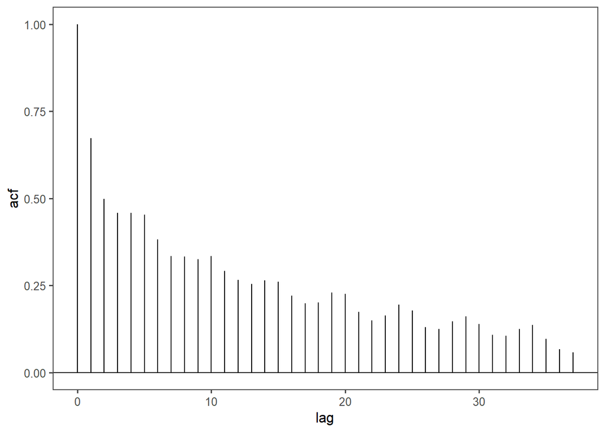

Figure 2: The autocorrelation function for log volume. We see that nearby values are fairly strongly correlated, with correlations above 0.2 as far as 20 days apart.

```r
ggacf(NYSE$log_volume) + ggthemes::theme_few()
```

Do a similar plot for (1) the correlation between $v_t$ and lag $\ell$ `Dow Jones return` $r_{t-\ell}$ and (2) correlation between $v_t$ and lag $\ell$ `Log volatility` $z_{t-\ell}$.

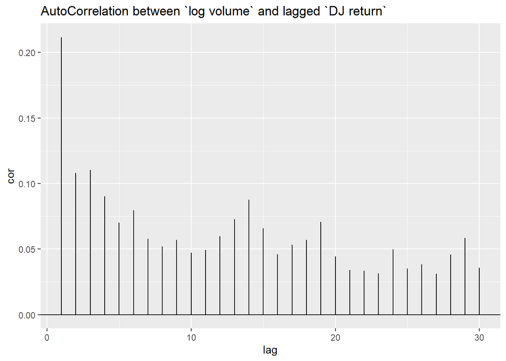

Figure 3: Correlations between log_volume and lagged DJ_return.

```r
seq(1, 30) %>%
  map(function(x) {cor(NYSE$log_volume , lag(NYSE$DJ_return, x), use = "pairwise.complete.obs")}) %>%
  unlist() %>%
  tibble(lag = 1:30, cor = .) %>%
  ggplot(aes(x = lag, y = cor)) +
  geom_hline(aes(yintercept = 0)) +
  geom_segment(mapping = aes(xend = lag, yend = 0)) +
  ggtitle("AutoCorrelation between `log volume` and lagged `DJ return`")
```

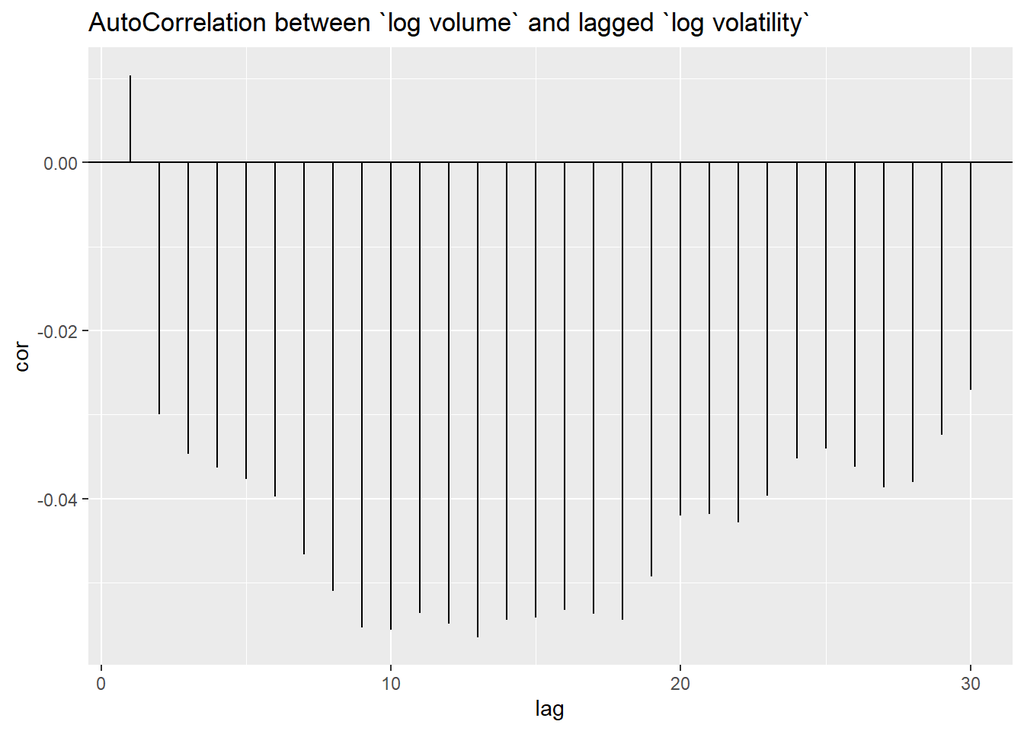

Figure 4: Weak correlations between log_volume and lagged log_volatility.

```r
seq(1, 30) %>%
  map(function(x) {cor(NYSE$log_volume , lag(NYSE$log_volatility, x), use = "pairwise.complete.obs")}) %>%
  unlist() %>%
  tibble(lag = 1:30, cor = .) %>%
  ggplot(aes(x = lag, y = cor)) +
  geom_hline(aes(yintercept = 0)) +
  geom_segment(mapping = aes(xend = lag, yend = 0)) +
  ggtitle("AutoCorrelation between `log volume` and lagged `log volatility`")
```

### 1.1 Project goal

Our goal is to forecast daily `Log trading volume`, using various machine learning algorithms we learnt in this class.

The data set is already split into train (before Jan 1st, 1980, $n_{\text{train}} = 4,281$) and test (after Jan 1st, 1980, $n_{\text{test}} = 1,770$) sets.

In general, we will tune the lag $L$ to acheive best forecasting performance. In this project, we would fix $L=5$. That is we always use the previous five trading days’ data to forecast today’s `log trading volume`.

Pay attention to the nuance of splitting time series data for cross validation. Study and use the [`time-series`](https://www.tidymodels.org/learn/models/time-series/) functionality in tidymodels. Make sure to use the same splits when tuning different machine learning algorithms.

Use the $R^2$ between forecast and actual values as the cross validation and test evaluation criterion.

### 1.2 Baseline method (20 pts)

We use the straw man (use yesterday’s value of `log trading volume` to predict that of today) as the baseline method. Evaluate the $R^2$ of this method on the test data.

Before we tune different machine learning methods, let’s first separate into the test and non-test sets. We drop the first 5 trading days which lack some lagged variables.

```r
# Lag: look back L trading days
# Do not need to include, as we included them in receipe
L = 5

for(i in seq(1, L)) {
  NYSE <- NYSE %>%
    mutate(!!paste("DJ_return_lag", i, sep = "") := lag(NYSE$DJ_return, i),
           !!paste("log_volume_lag", i, sep = "") := lag(NYSE$log_volume, i),
           !!paste("log_volatility_lag", i, sep = "") := lag(NYSE$log_volatility, i))
}


NYSE <- NYSE %>% na.omit()
```

```r
# Drop beginning trading days which lack some lagged variables
NYSE_other <- NYSE %>%
  filter(train == 'TRUE') %>%
  select(-train)

dim(NYSE_other)
```

```
[1] 4276   20
```

```r
NYSE_test = NYSE %>%
  filter(train == 'FALSE') %>%
  select(-train)

dim(NYSE_test)
```

```
[1] 1770   20
```

```r
library(yardstick)
# cor(NYSE_test$log_volume, NYSE_test$log_volume_lag1) %>% round(2)
r2_test_strawman =  rsq_vec(NYSE_test$log_volume, lag(NYSE_test$log_volume, 1)) %>% round(2)
print(paste("Straw man test R2: ", r2_test_strawman))
```

```
[1] "Straw man test R2:  0.35"
```

### 1.3 Autoregression (AR) forecaster (30 pts)

- Let
  $$y = \begin{pmatrix} v_{L+1} \\ v_{L+2} \\ v_{L+3} \\ \vdots \\ v_T \end{pmatrix}, \quad M = \begin{pmatrix}
  1 & v_L & v_{L-1} & \cdots & v_1 \\
  1 & v_{L+1} & v_{L} & \cdots & v_2 \\
  \vdots & \vdots & \vdots & \ddots & \vdots \\
  1 & v_{T-1} & v_{T-2} & \cdots & v_{T-L}
  \end{pmatrix}.$$
- Fit an ordinary least squares (OLS) regression of $y$ on $M$, giving
  $$\hat v_t = \hat \beta_0 + \hat \beta_1 v_{t-1} + \hat \beta_2 v_{t-2} + \cdots + \hat \beta_L v_{t-L},$$
  known as an **order-$L$ autoregression** model or **AR($L$)**.
- Before we start the model training, let’s talk about time series resampling. We will use the `rolling_origin` function in the `rsample` package to create a time series cross-validation plan.
- When the data have a strong time component, a resampling method should support modeling to estimate seasonal and other temporal trends within the data. A technique that randomly samples values from the training set can disrupt the model’s ability to estimate these patterns.

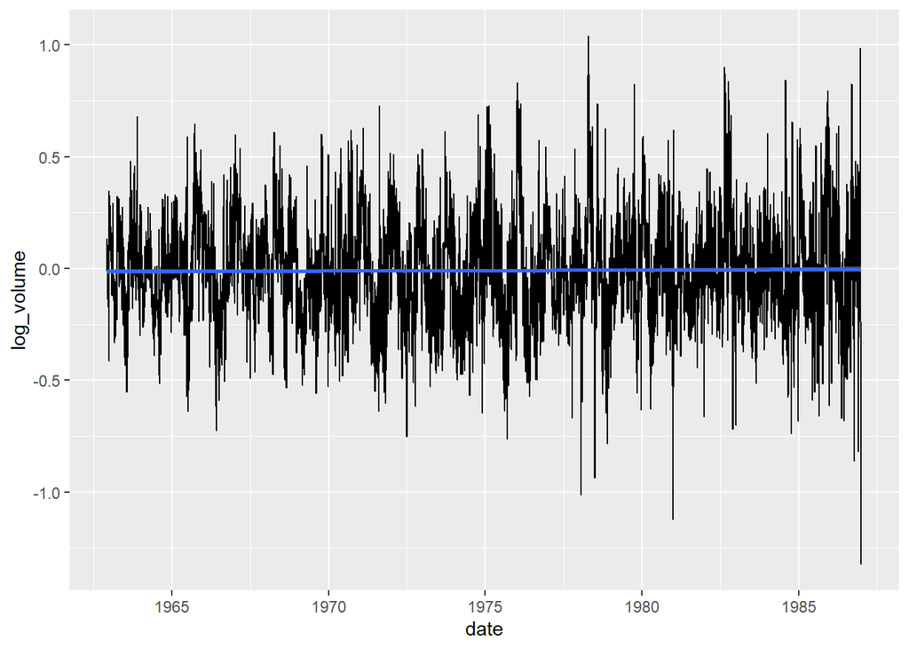

```r
NYSE %>%
  ggplot(aes(x = date, y = log_volume)) +
  geom_line() +
  geom_smooth(method = "lm")
```

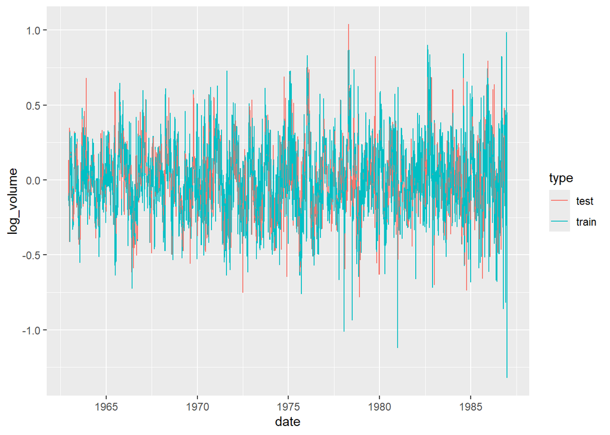

```r
wrong_split <- initial_split(NYSE)

bind_rows(
  training(wrong_split) %>% mutate(type = "train"),
  testing(wrong_split) %>% mutate(type = "test")
) %>%
  ggplot(aes(x = date, y = log_volume, color = type, group = NA)) +
  geom_line()
```

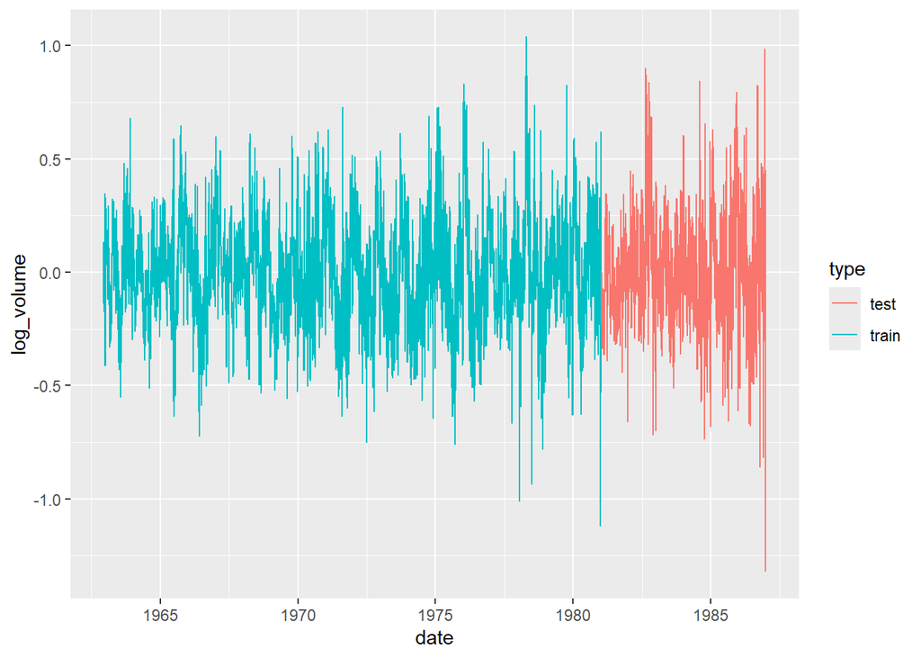

```r
correct_split <- initial_time_split(NYSE %>% arrange(date))

bind_rows(
  training(correct_split) %>% mutate(type = "train"),
  testing(correct_split) %>% mutate(type = "test")
) %>%
  ggplot(aes(x = date, y = log_volume, color = type, group = NA)) +
  geom_line()
```

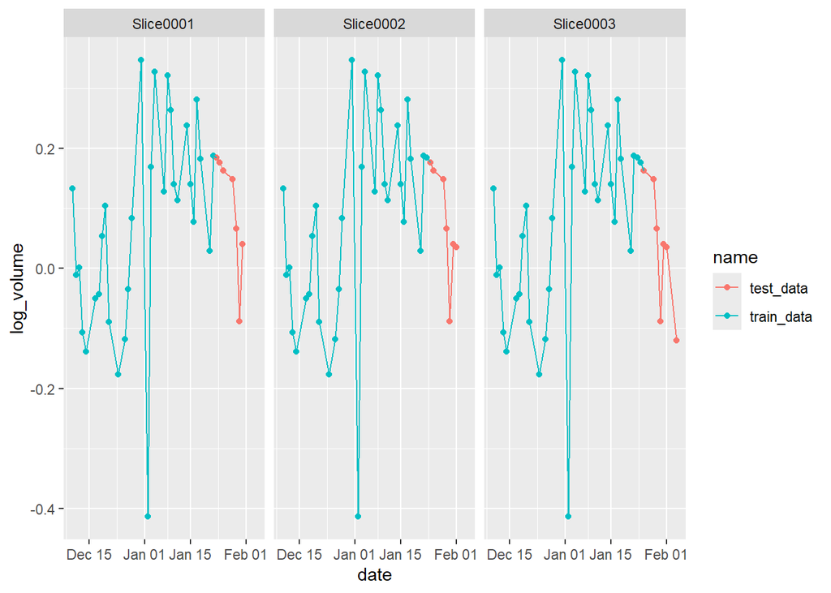

```r
rolling_origin(NYSE_other %>% arrange(date), initial = 30, assess = 7) %>%
  mutate(train_data = map(splits, analysis),
         test_data = map(splits, assessment)) %>%
  select(-splits) %>%
  pivot_longer(-id) %>%
  filter(id %in% c("Slice0001", "Slice0002", "Slice0003")) %>%
  unnest(value) %>%
  ggplot(aes(x = date, y = log_volume, color = name, group = NA)) +
  geom_point() +
  geom_line() +
  facet_wrap(~id, scales = "fixed")
```

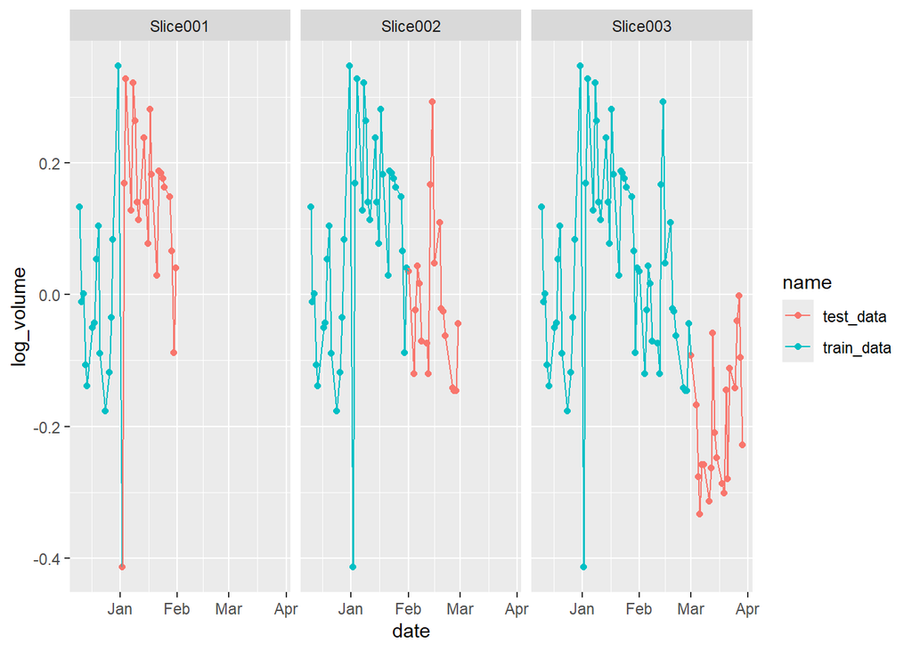

```r
sliding_period(NYSE_other %>% arrange(date),
               date, period = "month", lookback = Inf, assess_stop = 1) %>%
  mutate(train_data = map(splits, analysis),
         test_data = map(splits, assessment)) %>%
  select(-splits) %>%
  pivot_longer(-id) %>%
  filter(id %in% c("Slice001", "Slice002", "Slice003")) %>%
  unnest(value) %>%
  ggplot(aes(x = date, y = log_volume, color = name, group = NA)) +
  geom_point() +
  geom_line() +
  facet_wrap(~id, scales = "fixed")
```

- Rolling forecast origin resampling ([Hyndman and Athanasopoulos 2018](https://otexts.com/fpp3/)) provides a method that emulates how time series data is often partitioned in practice, estimating the model with historical data and evaluating it with the most recent data.
- Tune AR(5) with elastic net (enet + ridge) regularization using all 3 features on the training data, and evaluate the test performance.

#### 1.3.1 Preprocessing

```r
recipe <-
  recipe(log_volume ~ DJ_return_lag1 + DJ_return_lag2 + DJ_return_lag3 +
                      DJ_return_lag4 + DJ_return_lag5 + log_volume_lag1 +
                      log_volume_lag2 + log_volume_lag3 + log_volume_lag4 +
                      log_volume_lag5 + log_volatility_lag1 +
                      log_volatility_lag2 + log_volatility_lag3 +
                      log_volatility_lag4 + log_volatility_lag5,
         data = NYSE_other) %>%
  step_dummy(all_nominal()) %>%
  step_normalize(all_numeric_predictors()) %>%
  step_naomit(all_predictors())
  # prep(data = NYSE_other)
```

#### 1.3.2 Model training

```r
library(doParallel)

### Model
set.seed(203)

enet_mod <-
  # mixture = 0 (ridge), mixture = 1 (lasso)
  # mixture = (0, 1) elastic net
  linear_reg(penalty = tune(),
             mixture = 0.99) %>%
  set_engine("glmnet")
enet_mod

en_wf <-
  workflow() %>%
  add_model(enet_mod) %>%
  add_recipe(recipe)
en_wf

write_rds(en_wf, "en_wf.rds")

set.seed(203)
folds <- NYSE_other %>% arrange(date) %>%
    sliding_period(date, period = "month", lookback = Inf, assess_stop = 1)

month_folds <- NYSE_other %>%
  sliding_period(
    date,
    "month",
    lookback = Inf,
    skip = 4)

lambda_grid <-
  grid_regular(penalty(range = c(-15, 15),
                       trans = log10_trans()),
               levels = 30)
lambda_grid

# Register doParallel as the parallel backend as Random Forest is computationally expensive
# saving 2 cpu for other tasks
registerDoParallel(cores = detectCores()-2)

en_fit <- tune_grid(en_wf,
                    resamples = month_folds,
                    grid = lambda_grid,
                    metrics = metric_set(rmse, rsq))

# stop the registered parallel backend
stopImplicitCluster()

en_fit

write_rds(en_fit, "en_fit.rds")
```

```r
en_fit <- read_rds("en_fit.rds")
en_wf <- read_rds("en_wf.rds")

en_fit %>%
  show_best(metric = "rsq")
```

```
# A tibble: 5 × 7
   penalty .metric .estimator  mean     n std_err .config
     <dbl> <chr>   <chr>      <dbl> <int>   <dbl> <chr>
1 1   e-15 rsq     standard   0.250   200  0.0127 Preprocessor1_Model01
2 1.08e-14 rsq     standard   0.250   200  0.0127 Preprocessor1_Model02
3 1.17e-13 rsq     standard   0.250   200  0.0127 Preprocessor1_Model03
4 1.27e-12 rsq     standard   0.250   200  0.0127 Preprocessor1_Model04
5 1.37e-11 rsq     standard   0.250   200  0.0127 Preprocessor1_Model05
```

```r
best_enet <- en_fit %>%
  select_best(metric = "rsq")
best_enet
```

```
# A tibble: 1 × 2
  penalty .config
    <dbl> <chr>
1   1e-15 Preprocessor1_Model01
```

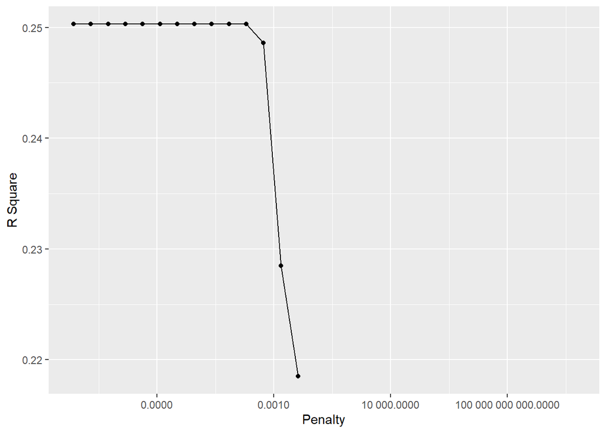

```r
en_fit %>% collect_metrics() %>%
  filter(.metric == "rsq") %>%
  ggplot(mapping = aes(x = penalty, y = mean)) +
  geom_point() +
  geom_line() +
  labs(x = "Penalty", y = "R Square") +
  scale_x_log10(labels = scales::label_number())
```

```r
# Final enet workflow
final_enet_wf <- en_wf %>%
  finalize_workflow(best_enet)
final_enet_wf
```

```
══ Workflow ════════════════════════════════════════════════════════════════════
Preprocessor: Recipe
Model: linear_reg()

── Preprocessor ────────────────────────────────────────────────────────────────
3 Recipe Steps

• step_dummy()
• step_normalize()
• step_naomit()

── Model ───────────────────────────────────────────────────────────────────────
Linear Regression Model Specification (regression)

Main Arguments:
  penalty = 1e-15
  mixture = 0.99

Computational engine: glmnet
```

```r
final_enet_fit <-
  final_enet_wf %>%
  last_fit(correct_split)
final_enet_fit %>% collect_metrics()
```

```
# A tibble: 2 × 4
  .metric .estimator .estimate .config
  <chr>   <chr>          <dbl> <chr>
1 rmse    standard       0.185 Preprocessor1_Model1
2 rsq     standard       0.404 Preprocessor1_Model1
```

- Hint: [Workflow: enet](https://ucla-biostat-212a.github.io/2024winter/slides/06-modelselection/workflow_enet.html) is a good starting point.

**Answer:** I changed the mixture parameter to 0.99 because in the process of tunning from 0 to 1 by an increment of 0.1 each time, I have discovered that the best performing mixture is closer to 1 (lasso). I also increased the range of the penalty term to (-15, 15) and used 30 levels to capture the maximum R Square. The elastic net model is decent at predicting the log volume with the test rsq being 0.4037 since the baseline model has a test rsq of 0.35 with an 0.0537 improvement. An rsq of 0.4037 means that approximately 40.37% of the variance in the outcome is predictable from the predictors in the model.

### 1.4 Random forest forecaster (30pts)

- Use the same features as in AR($L$) for the random forest. Tune the random forest and evaluate the test performance.
- Hint: [Workflow: Random Forest for Prediction](https://ucla-biostat-212a.github.io/2024winter/slides/08-tree/workflow_rf_reg.html) is a good starting point.

#### 1.4.1 Preprocessing

**Answer:** Same recipe as before since same dataset is used.

#### 1.4.2 Model training

```r
library(doParallel)
library(ranger)

set.seed(203)
### Model
rf_mod <-
  rand_forest(
    mode = "regression",
    # Number of predictors randomly sampled in each split
    mtry = tune(),
    # Number of trees in ensemble
    trees = tune()
  ) %>%
  set_engine("ranger")
rf_mod

rf_wf <-
  workflow() %>%
  add_model(rf_mod) %>%
  add_recipe(recipe)
  # add_recipe(recipe %>% step_rm(date) %>% step_indicate_na())
rf_wf

write_rds(rf_wf, "rf_wf.rds")

set.seed(203)
folds <- NYSE_other %>% arrange(date) %>%
    sliding_period(date, period = "month", lookback = Inf, assess_stop = 1)
  # rolling_origin(initial = 5, assess = 1)


month_folds <- NYSE_other %>%
  sliding_period(
    date,
    "month",
    lookback = Inf,
    skip = 4)

rf_grid <-
  grid_regular(
    trees(range = c(500L, 600L)),
    mtry(range = c(3L, 5L)),
    levels = c(2, 2))
rf_grid

# Register doParallel as the parallel backend as Random Forest is computationally expensive
# saving 2 cpu for other tasks
registerDoParallel(cores = detectCores()-2)

rf_fit <- tune_grid(rf_wf, resamples = month_folds,
                    grid = rf_grid, metrics = metric_set(rmse, rsq))

# stop the registered parallel backend
stopImplicitCluster()

write_rds(rf_fit, "rf_fit.rds")
```

```r
rf_fit <- read_rds("rf_fit.rds")
rf_wf <- read_rds("rf_wf.rds")

rf_fit %>%
  show_best(metric = "rsq")
```

```
# A tibble: 4 × 8
   mtry trees .metric .estimator  mean     n std_err .config
  <int> <int> <chr>   <chr>      <dbl> <int>   <dbl> <chr>
1     5   600 rsq     standard   0.250   200  0.0129 Preprocessor1_Model4
2     5   500 rsq     standard   0.250   200  0.0128 Preprocessor1_Model3
3     3   500 rsq     standard   0.247   200  0.0129 Preprocessor1_Model1
4     3   600 rsq     standard   0.246   200  0.0130 Preprocessor1_Model2
```

```r
best_rf <- rf_fit %>%
  select_best(metric = "rsq")
best_rf
```

```
# A tibble: 1 × 3
   mtry trees .config
  <int> <int> <chr>
1     5   600 Preprocessor1_Model4
```

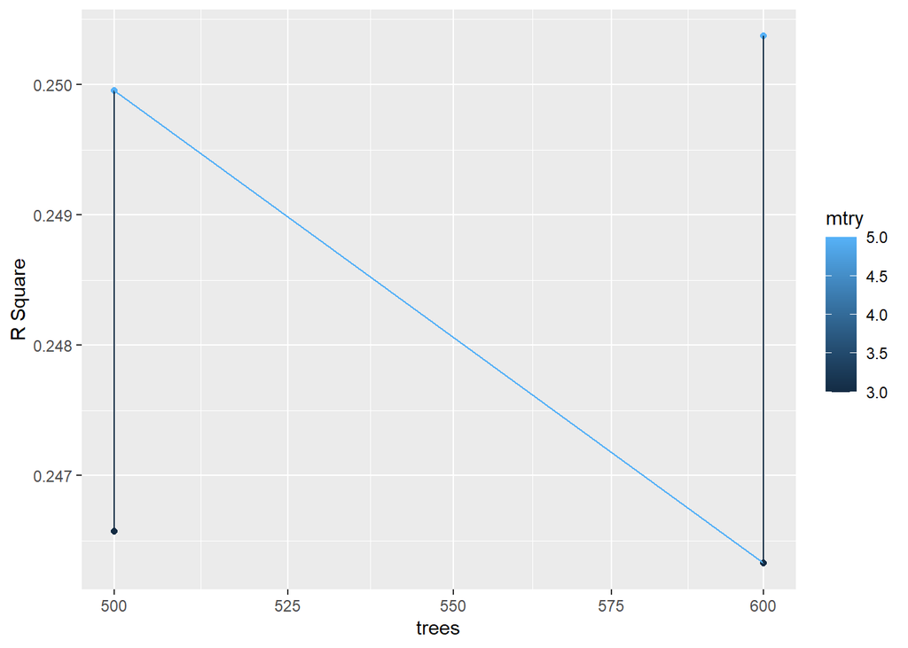

```r
rf_fit %>%
    collect_metrics() %>%
    filter(.metric == "rsq") %>%
    ggplot(mapping = aes(x = trees,
                         y = mean,
                         color = mtry)) +
      geom_point() +
      geom_line() +
      labs(x = "trees", y = "R Square") +
      scale_x_log10(labels = scales::label_number())
```

```r
rf_fit
```

```
# Tuning results
# Sliding period resampling
# A tibble: 200 × 4
   splits           id       .metrics         .notes
   <list>           <chr>    <list>           <list>
 1 <split [98/22]>  Slice001 <tibble [8 × 6]> <tibble [0 × 3]>
 2 <split [120/20]> Slice002 <tibble [8 × 6]> <tibble [0 × 3]>
 3 <split [140/22]> Slice003 <tibble [8 × 6]> <tibble [0 × 3]>
 4 <split [162/22]> Slice004 <tibble [8 × 6]> <tibble [0 × 3]>
 5 <split [184/20]> Slice005 <tibble [8 × 6]> <tibble [0 × 3]>
 6 <split [204/23]> Slice006 <tibble [8 × 6]> <tibble [0 × 3]>
 7 <split [227/18]> Slice007 <tibble [8 × 6]> <tibble [0 × 3]>
 8 <split [245/21]> Slice008 <tibble [8 × 6]> <tibble [0 × 3]>
 9 <split [266/22]> Slice009 <tibble [8 × 6]> <tibble [0 × 3]>
10 <split [288/19]> Slice010 <tibble [8 × 6]> <tibble [0 × 3]>
# ℹ 190 more rows
```

```r
# Final enet workflow
final_rf_wf <- rf_wf %>%
  finalize_workflow(best_rf)
final_rf_wf
```

```
══ Workflow ════════════════════════════════════════════════════════════════════
Preprocessor: Recipe
Model: rand_forest()

── Preprocessor ────────────────────────────────────────────────────────────────
3 Recipe Steps

• step_dummy()
• step_normalize()
• step_naomit()

── Model ───────────────────────────────────────────────────────────────────────
Random Forest Model Specification (regression)

Main Arguments:
  mtry = 5
  trees = 600

Computational engine: ranger
```

```r
final_rf_fit <-
  final_rf_wf %>%
  last_fit(correct_split)
final_rf_fit %>% collect_metrics()
```

```
# A tibble: 2 × 4
  .metric .estimator .estimate .config
  <chr>   <chr>          <dbl> <chr>
1 rmse    standard       0.187 Preprocessor1_Model1
2 rsq     standard       0.385 Preprocessor1_Model1
```

### 1.5 Boosting forecaster (30pts)

- Use the same features as in AR($L$) for the boosting. Tune the boosting algorithm and evaluate the test performance.
- Hint: [Workflow: Boosting tree for Prediction](https://ucla-biostat-212a.github.io/2024winter/slides/08-tree/workflow_boosting_reg.html) is a good starting point.

#### 1.5.1 Preprocessing

**Answer:** Same recipe as before since same dataset is used.

#### 1.5.2 Model training

```r
library(doParallel)
library(xgboost)

gb_mod <-
  boost_tree(
    mode = "regression",
    trees = 500,
    tree_depth = tune(),
    learn_rate = tune()
  ) %>%
  set_engine("xgboost")
gb_mod

gb_wf <-
  workflow() %>%
  add_model(gb_mod) %>%
  add_recipe(recipe)
  # add_recipe(recipe %>% step_rm(date) %>% step_indicate_na())
gb_wf

write_rds(gb_wf, "gb_wf.rds")

folds <- NYSE_other %>% arrange(date) %>%
    sliding_period(date, period = "month", lookback = Inf, assess_stop = 1)
  # rolling_origin(initial = 5, assess = 1)


month_folds <- NYSE_other %>%
  sliding_period(
    date,
    "month",
    lookback = Inf,
    skip = 4)

gb_grid <-
  grid_regular(
      tree_depth(range = c(1L, 3L)),
      learn_rate(range = c(-3, 1), trans = log10_trans()),
      levels = c(3, 4))
gb_grid

# Register doParallel as the parallel backend
# saving 2 cpu for other tasks
registerDoParallel(cores = detectCores()-2)

gb_fit <- tune_grid(gb_wf, resamples = month_folds, grid = gb_grid, metrics = metric_set(rmse, rsq))

# stop the registered parallel backend
stopImplicitCluster()

write_rds(gb_fit, "gb_fit.rds")
```

```r
gb_fit <- read_rds("gb_fit.rds")
gb_wf <- read_rds("gb_wf.rds")

gb_fit %>%
  show_best(metric = "rsq")
```

```
# A tibble: 5 × 8
  tree_depth learn_rate .metric .estimator  mean     n std_err .config
       <int>      <dbl> <chr>   <chr>      <dbl> <int>   <dbl> <chr>
1          3     0.0215 rsq     standard   0.257   200  0.0132 Preprocessor1_Mo…
2          2     0.0215 rsq     standard   0.256   200  0.0130 Preprocessor1_Mo…
3          1     0.0215 rsq     standard   0.244   200  0.0126 Preprocessor1_Mo…
4          1     0.464  rsq     standard   0.231   200  0.0122 Preprocessor1_Mo…
5          3     0.001  rsq     standard   0.217   200  0.0120 Preprocessor1_Mo…
```

```r
best_gb <- gb_fit %>%
  select_best(metric = "rsq")
best_gb
```

```
# A tibble: 1 × 3
  tree_depth learn_rate .config
       <int>      <dbl> <chr>
1          3     0.0215 Preprocessor1_Model06
```

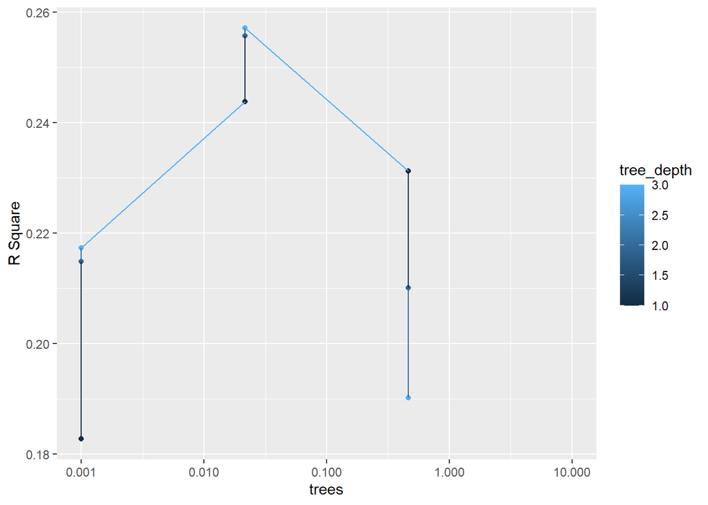

```r
gb_fit %>%
    collect_metrics() %>%
    filter(.metric == "rsq") %>%
    ggplot(mapping = aes(x = learn_rate,
                         y = mean,
                         color = tree_depth)) +
      geom_point() +
      geom_line() +
      labs(x = "trees", y = "R Square") +
      scale_x_log10(labels = scales::label_number())
```

```r
gb_fit
```

```
# Tuning results
# Sliding period resampling
# A tibble: 200 × 4
   splits           id       .metrics          .notes
   <list>           <chr>    <list>            <list>
 1 <split [98/22]>  Slice001 <tibble [24 × 6]> <tibble [1 × 3]>
 2 <split [120/20]> Slice002 <tibble [24 × 6]> <tibble [1 × 3]>
 3 <split [140/22]> Slice003 <tibble [24 × 6]> <tibble [1 × 3]>
 4 <split [162/22]> Slice004 <tibble [24 × 6]> <tibble [1 × 3]>
 5 <split [184/20]> Slice005 <tibble [24 × 6]> <tibble [1 × 3]>
 6 <split [204/23]> Slice006 <tibble [24 × 6]> <tibble [1 × 3]>
 7 <split [227/18]> Slice007 <tibble [24 × 6]> <tibble [1 × 3]>
 8 <split [245/21]> Slice008 <tibble [24 × 6]> <tibble [1 × 3]>
 9 <split [266/22]> Slice009 <tibble [24 × 6]> <tibble [1 × 3]>
10 <split [288/19]> Slice010 <tibble [24 × 6]> <tibble [1 × 3]>
# ℹ 190 more rows

There were issues with some computations:

  - Warning(s) x1: A correlation computation is required, but `estimate` is constant...
  - Warning(s) x199: A correlation computation is required, but the inputs are size ze...

Run `show_notes(.Last.tune.result)` for more information.
```

```r
# Final boosting workflow
final_gb_wf <- gb_wf %>%
  finalize_workflow(best_gb)
final_gb_wf
```

```
══ Workflow ════════════════════════════════════════════════════════════════════
Preprocessor: Recipe
Model: boost_tree()

── Preprocessor ────────────────────────────────────────────────────────────────
3 Recipe Steps

• step_dummy()
• step_normalize()
• step_naomit()

── Model ───────────────────────────────────────────────────────────────────────
Boosted Tree Model Specification (regression)

Main Arguments:
  trees = 500
  tree_depth = 3
  learn_rate = 0.0215443469003188

Computational engine: xgboost
```

```r
final_gb_fit <-
  final_gb_wf %>%
  last_fit(correct_split)
final_gb_fit %>% collect_metrics()
```

```
# A tibble: 2 × 4
  .metric .estimator .estimate .config
  <chr>   <chr>          <dbl> <chr>
1 rmse    standard       0.185 Preprocessor1_Model1
2 rsq     standard       0.405 Preprocessor1_Model1
```

**Answer:** Due to limited computing resources, I tuned with small ranges of tree_depth and learn_rate to locate the optimal tunning parameters to capture the maximum R Square. The boosting method is decent at predicting the log volume with the test rsq being 0.4050 since the baseline model has a test rsq of 0.35. An rsq of 0.4050 means that approximately 40.50% of the variance in the outcome is predictable from the predictors in the model.

### 1.6 Summary (30pts)

Your score for this question is largely determined by your final test performance.

Summarize the performance of different machine learning forecasters in the following format.

[output not shown]

Noteably, all models have a lower CV R2 than the test R2. This could be a sign of underfitting possbily. Due to my limited computing resources I am not able to fully explore the hyperparameter space for the optimal models given the time constraint. It could also be due to the outliers or the noise in the training data.

### 1.7 Extension reading

- [MOIRAI: Salesforce’s Foundation Model for Time-Series Forecasting](https://towardsdatascience.com/moirai-salesforces-foundation-model-for-time-series-forecasting-4eff6c34093d)

## 2 ISL Exercise 12.6.13 (90 pts)

On the book website, www.statlearning.com, there is a gene expres- sion data set (Ch12Ex13.csv) that consists of 40 tissue samples with measurements on 1,000 genes. The first 20 samples are from healthy patients, while the second 20 are from a diseased group.

1. Load in the data using read.csv(). You will need to select header = F.

```r
library(tidyverse)
# Read in the gene expression data from url
url = "https://raw.githubusercontent.com/ucla-biostat-212a/2024winter/master/slides/data/Ch12Ex13.csv"
gene_exp <- read.csv(url, header = FALSE)
# gene_exp_dist = as.dist(1-cor(gene_exp))
```

### 2.1 12.6.13 (b) (30 pts)

2. Apply hierarchical clustering to the samples using correlation- based distance, and plot the dendrogram. Do the genes separate the samples into the two groups? Do your results depend on the type of linkage used?

#### 2.1.1 single linkage

```r
library(tidyclust)

hc_spec <- hier_clust(
  num_clusters = 2,
  linkage_method = "single"
)

hc_spec
```

```
Hierarchical Clustering Specification (partition)

Main Arguments:
  num_clusters = 2
  linkage_method = single

Computational engine: stats
```

```r
hc_fit <- hc_spec %>%
  fit(~ .,
    data = as.data.frame(t(gene_exp))
  )

hc_fit %>%
  summary()
```

```
        Length Class      Mode
spec    4      hier_clust list
fit     7      hclust     list
elapsed 1      -none-     list
preproc 4      -none-     list
```

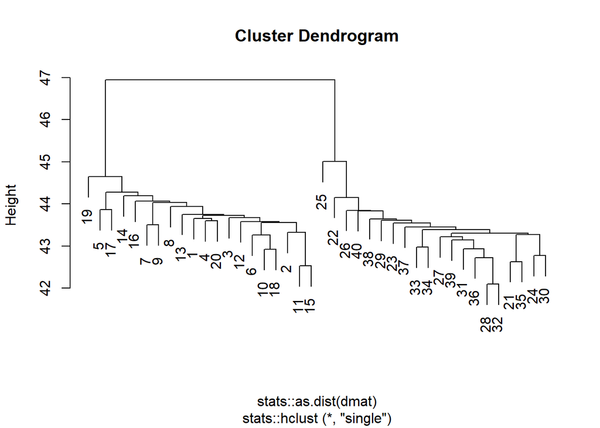

```r
hc_fit$fit %>% plot()
```

```r
hc_summary <- hc_fit %>% extract_fit_summary()

hc_summary %>% str()
```

[output not shown]

[output cut: 53 more lines]

```
  ..$ V91  : num [1:2] -0.00968 -0.31858
  ..$ V92  : num [1:2] -0.1392 0.0904
  ..$ V93  : num [1:2] -0.1302 -0.0224
  ..$ V94  : num [1:2] -0.456 -0.113
  ..$ V95  : num [1:2] 0.268 0.484
  ..$ V96  : num [1:2] 0.14 -0.223
  ..$ V97  : num [1:2] -0.0973 -0.3869
  ..$ V98  : num [1:2] 0.324 -0.233
  ..$ V99  : num [1:2] 0.12412 0.00848
  .. [list output truncated]
 $ n_members             : int [1:2] 20 20
 $ sse_within_total_total: num [1:2] 622 617
 $ sse_total             : num 1325
 $ orig_labels           : NULL
 $ cluster_assignments   : Factor w/ 2 levels "Cluster_1","Cluster_2": 1 1 1 1 1 1 1 1 1 1 ...
```

```r
hc_fit %>% extract_centroids()
```

```
# A tibble: 2 × 1,001
  .cluster      V1     V2      V3      V4      V5      V6     V7     V8     V9
  <fct>      <dbl>  <dbl>   <dbl>   <dbl>   <dbl>   <dbl>  <dbl>  <dbl>  <dbl>
1 Cluster_1 0.135  -0.197 -0.182  -0.332  -0.271  -0.0964 -0.184 0.168  -0.156
2 Cluster_2 0.0492 -0.216  0.0747  0.0789 -0.0960  0.338  -0.120 0.0853 -0.211
# ℹ 991 more variables: V10 <dbl>, V11 <dbl>, V12 <dbl>, V13 <dbl>, V14 <dbl>,
#   V15 <dbl>, V16 <dbl>, V17 <dbl>, V18 <dbl>, V19 <dbl>, V20 <dbl>,
#   V21 <dbl>, V22 <dbl>, V23 <dbl>, V24 <dbl>, V25 <dbl>, V26 <dbl>,
#   V27 <dbl>, V28 <dbl>, V29 <dbl>, V30 <dbl>, V31 <dbl>, V32 <dbl>,
#   V33 <dbl>, V34 <dbl>, V35 <dbl>, V36 <dbl>, V37 <dbl>, V38 <dbl>,
#   V39 <dbl>, V40 <dbl>, V41 <dbl>, V42 <dbl>, V43 <dbl>, V44 <dbl>,
#   V45 <dbl>, V46 <dbl>, V47 <dbl>, V48 <dbl>, V49 <dbl>, V50 <dbl>, …
```

```r
hc_preds <- hc_fit %>% predict(as.data.frame(t(gene_exp)))

hc_preds
```

```
# A tibble: 40 × 1
   .pred_cluster
   <fct>
 1 Cluster_1
 2 Cluster_1
 3 Cluster_1
 4 Cluster_1
 5 Cluster_1
 6 Cluster_1
 7 Cluster_1
 8 Cluster_1
 9 Cluster_1
10 Cluster_1
# ℹ 30 more rows
```

```r
bind_cols(
  hc_preds,
  extract_cluster_assignment(hc_fit)
)
```

```
# A tibble: 40 × 2
   .pred_cluster .cluster
   <fct>         <fct>
 1 Cluster_1     Cluster_1
 2 Cluster_1     Cluster_1
 3 Cluster_1     Cluster_1
 4 Cluster_1     Cluster_1
 5 Cluster_1     Cluster_1
 6 Cluster_1     Cluster_1
 7 Cluster_1     Cluster_1
 8 Cluster_1     Cluster_1
 9 Cluster_1     Cluster_1
10 Cluster_1     Cluster_1
# ℹ 30 more rows
```

#### 2.1.2 Average linkage

```r
library(tidyclust)

hc_spec <- hier_clust(
  num_clusters = 2,
  linkage_method = "average"
)

hc_spec
```

```
Hierarchical Clustering Specification (partition)

Main Arguments:
  num_clusters = 2
  linkage_method = average

Computational engine: stats
```

```r
hc_fit <- hc_spec %>%
  fit(~ .,
    data = as.data.frame(t(gene_exp))
  )

hc_fit %>%
  summary()
```

```
        Length Class      Mode
spec    4      hier_clust list
fit     7      hclust     list
elapsed 1      -none-     list
preproc 4      -none-     list
```

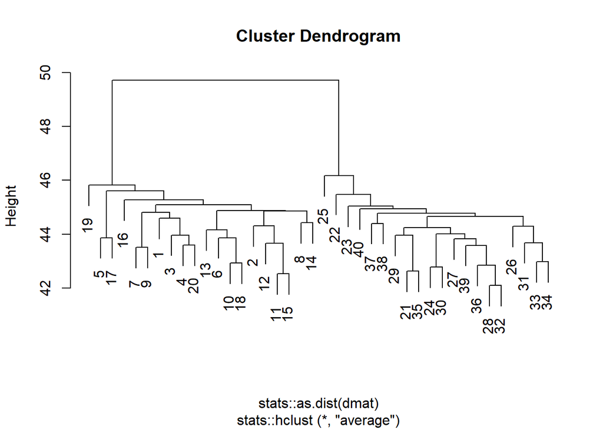

```r
hc_fit$fit %>% plot()
```

```r
hc_summary <- hc_fit %>% extract_fit_summary()

hc_summary %>% str()
```

[output not shown]

[output cut: 53 more lines]

```
  ..$ V91  : num [1:2] -0.00968 -0.31858
  ..$ V92  : num [1:2] -0.1392 0.0904
  ..$ V93  : num [1:2] -0.1302 -0.0224
  ..$ V94  : num [1:2] -0.456 -0.113
  ..$ V95  : num [1:2] 0.268 0.484
  ..$ V96  : num [1:2] 0.14 -0.223
  ..$ V97  : num [1:2] -0.0973 -0.3869
  ..$ V98  : num [1:2] 0.324 -0.233
  ..$ V99  : num [1:2] 0.12412 0.00848
  .. [list output truncated]
 $ n_members             : int [1:2] 20 20
 $ sse_within_total_total: num [1:2] 622 617
 $ sse_total             : num 1325
 $ orig_labels           : NULL
 $ cluster_assignments   : Factor w/ 2 levels "Cluster_1","Cluster_2": 1 1 1 1 1 1 1 1 1 1 ...
```

```r
hc_fit %>% extract_centroids()
```

```
# A tibble: 2 × 1,001
  .cluster      V1     V2      V3      V4      V5      V6     V7     V8     V9
  <fct>      <dbl>  <dbl>   <dbl>   <dbl>   <dbl>   <dbl>  <dbl>  <dbl>  <dbl>
1 Cluster_1 0.135  -0.197 -0.182  -0.332  -0.271  -0.0964 -0.184 0.168  -0.156
2 Cluster_2 0.0492 -0.216  0.0747  0.0789 -0.0960  0.338  -0.120 0.0853 -0.211
# ℹ 991 more variables: V10 <dbl>, V11 <dbl>, V12 <dbl>, V13 <dbl>, V14 <dbl>,
#   V15 <dbl>, V16 <dbl>, V17 <dbl>, V18 <dbl>, V19 <dbl>, V20 <dbl>,
#   V21 <dbl>, V22 <dbl>, V23 <dbl>, V24 <dbl>, V25 <dbl>, V26 <dbl>,
#   V27 <dbl>, V28 <dbl>, V29 <dbl>, V30 <dbl>, V31 <dbl>, V32 <dbl>,
#   V33 <dbl>, V34 <dbl>, V35 <dbl>, V36 <dbl>, V37 <dbl>, V38 <dbl>,
#   V39 <dbl>, V40 <dbl>, V41 <dbl>, V42 <dbl>, V43 <dbl>, V44 <dbl>,
#   V45 <dbl>, V46 <dbl>, V47 <dbl>, V48 <dbl>, V49 <dbl>, V50 <dbl>, …
```

```r
hc_preds <- hc_fit %>% predict(as.data.frame(t(gene_exp)))

hc_preds
```

```
# A tibble: 40 × 1
   .pred_cluster
   <fct>
 1 Cluster_1
 2 Cluster_1
 3 Cluster_1
 4 Cluster_1
 5 Cluster_1
 6 Cluster_1
 7 Cluster_1
 8 Cluster_1
 9 Cluster_1
10 Cluster_1
# ℹ 30 more rows
```

```r
bind_cols(
  hc_preds,
  extract_cluster_assignment(hc_fit)
)
```

```
# A tibble: 40 × 2
   .pred_cluster .cluster
   <fct>         <fct>
 1 Cluster_1     Cluster_1
 2 Cluster_1     Cluster_1
 3 Cluster_1     Cluster_1
 4 Cluster_1     Cluster_1
 5 Cluster_1     Cluster_1
 6 Cluster_1     Cluster_1
 7 Cluster_1     Cluster_1
 8 Cluster_1     Cluster_1
 9 Cluster_1     Cluster_1
10 Cluster_1     Cluster_1
# ℹ 30 more rows
```

#### 2.1.3 complete linkage

```r
library(tidyclust)

hc_spec <- hier_clust(
  num_clusters = 2,
  linkage_method = "complete"
)

hc_spec
```

```
Hierarchical Clustering Specification (partition)

Main Arguments:
  num_clusters = 2
  linkage_method = complete

Computational engine: stats
```

```r
hc_fit <- hc_spec %>%
  fit(~ .,
    data = as.data.frame(t(gene_exp))
  )

hc_fit %>%
  summary()
```

```
        Length Class      Mode
spec    4      hier_clust list
fit     7      hclust     list
elapsed 1      -none-     list
preproc 4      -none-     list
```

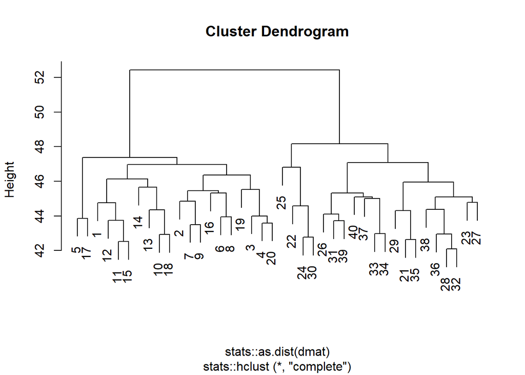

```r
hc_fit$fit %>% plot()
```

```r
hc_summary <- hc_fit %>% extract_fit_summary()

hc_summary %>% str()
```

[output not shown]

[output cut: 53 more lines]

```
  ..$ V91  : num [1:2] -0.00968 -0.31858
  ..$ V92  : num [1:2] -0.1392 0.0904
  ..$ V93  : num [1:2] -0.1302 -0.0224
  ..$ V94  : num [1:2] -0.456 -0.113
  ..$ V95  : num [1:2] 0.268 0.484
  ..$ V96  : num [1:2] 0.14 -0.223
  ..$ V97  : num [1:2] -0.0973 -0.3869
  ..$ V98  : num [1:2] 0.324 -0.233
  ..$ V99  : num [1:2] 0.12412 0.00848
  .. [list output truncated]
 $ n_members             : int [1:2] 20 20
 $ sse_within_total_total: num [1:2] 622 617
 $ sse_total             : num 1325
 $ orig_labels           : NULL
 $ cluster_assignments   : Factor w/ 2 levels "Cluster_1","Cluster_2": 1 1 1 1 1 1 1 1 1 1 ...
```

```r
hc_fit %>% extract_centroids()
```

```
# A tibble: 2 × 1,001
  .cluster      V1     V2      V3      V4      V5      V6     V7     V8     V9
  <fct>      <dbl>  <dbl>   <dbl>   <dbl>   <dbl>   <dbl>  <dbl>  <dbl>  <dbl>
1 Cluster_1 0.135  -0.197 -0.182  -0.332  -0.271  -0.0964 -0.184 0.168  -0.156
2 Cluster_2 0.0492 -0.216  0.0747  0.0789 -0.0960  0.338  -0.120 0.0853 -0.211
# ℹ 991 more variables: V10 <dbl>, V11 <dbl>, V12 <dbl>, V13 <dbl>, V14 <dbl>,
#   V15 <dbl>, V16 <dbl>, V17 <dbl>, V18 <dbl>, V19 <dbl>, V20 <dbl>,
#   V21 <dbl>, V22 <dbl>, V23 <dbl>, V24 <dbl>, V25 <dbl>, V26 <dbl>,
#   V27 <dbl>, V28 <dbl>, V29 <dbl>, V30 <dbl>, V31 <dbl>, V32 <dbl>,
#   V33 <dbl>, V34 <dbl>, V35 <dbl>, V36 <dbl>, V37 <dbl>, V38 <dbl>,
#   V39 <dbl>, V40 <dbl>, V41 <dbl>, V42 <dbl>, V43 <dbl>, V44 <dbl>,
#   V45 <dbl>, V46 <dbl>, V47 <dbl>, V48 <dbl>, V49 <dbl>, V50 <dbl>, …
```

```r
hc_preds <- hc_fit %>% predict(as.data.frame(t(gene_exp)))

hc_preds
```

```
# A tibble: 40 × 1
   .pred_cluster
   <fct>
 1 Cluster_1
 2 Cluster_1
 3 Cluster_1
 4 Cluster_1
 5 Cluster_1
 6 Cluster_1
 7 Cluster_1
 8 Cluster_1
 9 Cluster_1
10 Cluster_1
# ℹ 30 more rows
```

```r
bind_cols(
  hc_preds,
  extract_cluster_assignment(hc_fit)
)
```

```
# A tibble: 40 × 2
   .pred_cluster .cluster
   <fct>         <fct>
 1 Cluster_1     Cluster_1
 2 Cluster_1     Cluster_1
 3 Cluster_1     Cluster_1
 4 Cluster_1     Cluster_1
 5 Cluster_1     Cluster_1
 6 Cluster_1     Cluster_1
 7 Cluster_1     Cluster_1
 8 Cluster_1     Cluster_1
 9 Cluster_1     Cluster_1
10 Cluster_1     Cluster_1
# ℹ 30 more rows
```

**Answer:** The genes separated the samples into the two groups as shown in the dendrograms. Similar results were produced by the three linkage methods.

### 2.2 PCA and UMAP (30 pts)

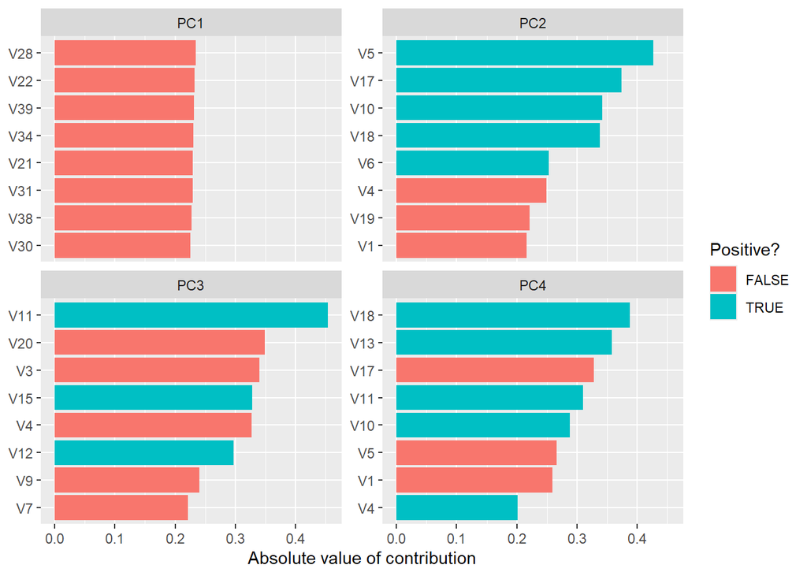

```r
library(tidymodels)
pca_rec <- recipe(~., data = gene_exp) %>%
  step_normalize(all_predictors()) %>%
  step_pca(all_predictors())
pca_prep <- prep(pca_rec)
pca_prep

library(tidytext)
tidied_pca <- tidy(pca_prep, 2)


tidied_pca %>%
  filter(component %in% paste0("PC", 1:4)) %>%
  group_by(component) %>%
  top_n(8, abs(value)) %>%
  ungroup() %>%
  mutate(terms = reorder_within(terms, abs(value), component)) %>%
  ggplot(aes(abs(value), terms, fill = value > 0)) +
  geom_col() +
  facet_wrap(~component, scales = "free_y") +
  scale_y_reordered() +
  labs(
    x = "Absolute value of contribution",
    y = NULL, fill = "Positive?"
  )
```

**Answer:** To comment on the most important component, the principle component 1 which captures the maximum variance in the data. In this context all the variables namely in the range of the diseased group have similar and substantial contributions to PC1, indicated by the length of the bars. They are all colored red, meaning their contribution is marked as “FALSE”, this could mean their contribution to PC1 is negative which matches with the information that we have known from the data documentation.

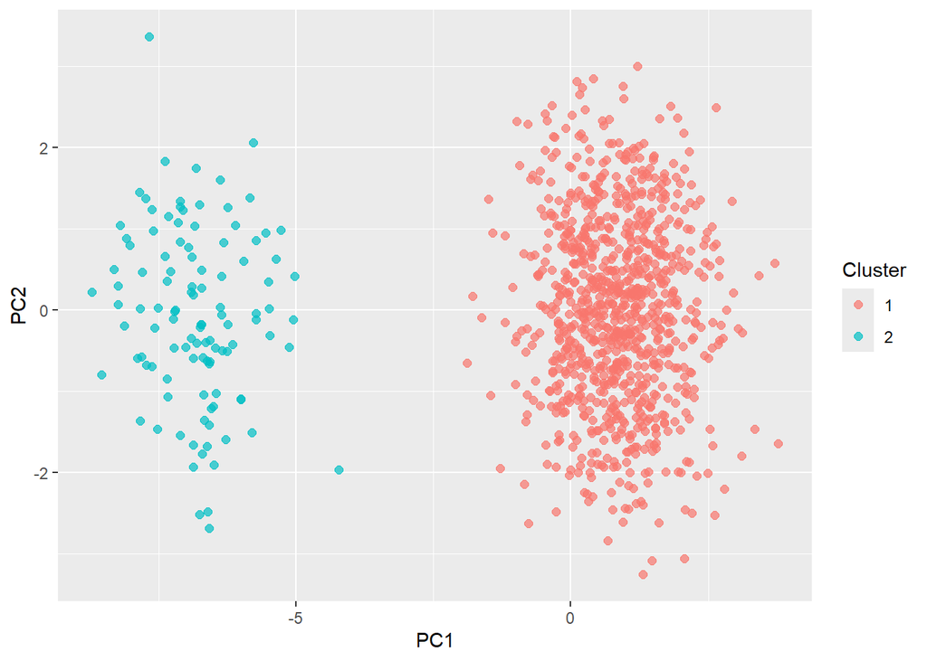

```r
pca_results <- juice(pca_prep)

set.seed(203) # For reproducibility
clusters <- kmeans(pca_results[, c("PC1", "PC2")], centers = 2)

#add the cluster assignments
pca_results$Cluster <- as.factor(clusters$cluster)

#plot the clusters
ggplot(pca_results, aes(PC1, PC2, color = Cluster)) +
  geom_point(alpha = 0.7, size = 2) +
  labs(color = "Cluster")
```

**Answer:** It is apparent that the two groups are well separated in the PCA plot. There is clear seggregation between the two groups.

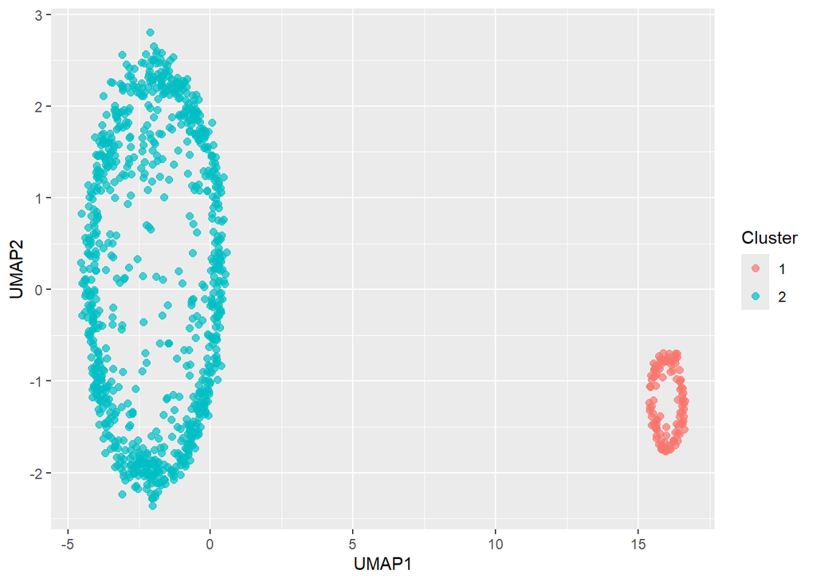

```r
library(embed)
umap_rec <- recipe(~., data = gene_exp) %>%
  step_normalize(all_predictors()) %>%
  step_umap(all_predictors())
umap_prep <- prep(umap_rec)
umap_prep

umap_results <- juice(umap_prep)

set.seed(203) # For reproducibility
clusters <- kmeans(umap_results[, c("UMAP1", "UMAP2")], centers = 2)

#add the cluster assignments
umap_results$Cluster <- as.factor(clusters$cluster)

#plot the clusters
ggplot(umap_results, aes(UMAP1, UMAP2, color = Cluster)) +
  geom_point(alpha = 0.7, size = 2) +
  labs(color = "Cluster")
```

**Answer:** With UMAP, the local neighborhood is preserved and it will not be strictly linear in nature. It is clear that in this case the clusters seems to form oval patterns while still showing the separation of the two distinct groups. There is clear seggregation between the two groups With cluster 2 having a having much more spread.

### 2.3 12.6.13 (c) (30 pts)

3. Your collaborator wants to know which genes differ the most across the two groups. Suggest a way to answer this question, and apply it here.

```r
library(tidyverse)

url = "https://raw.githubusercontent.com/ucla-biostat-212a/2024winter/master/slides/data/Ch12Ex13.csv"
Ch12Ex13 <- read_csv(url, col_names = paste("ID", 1:40, sep = ""))
```

```r
library(tidyclust)

set.seed(838383)
hc_spec <- hier_clust(
  # num_clusters = 3,
  linkage_method = "average"
)


hc_fit <- hc_spec %>%
  fit(~ .,
    data = as.data.frame(t(Ch12Ex13))
  )

hc_fit %>%
  summary()
```

```
        Length Class      Mode
spec    4      hier_clust list
fit     7      hclust     list
elapsed 1      -none-     list
preproc 4      -none-     list
```

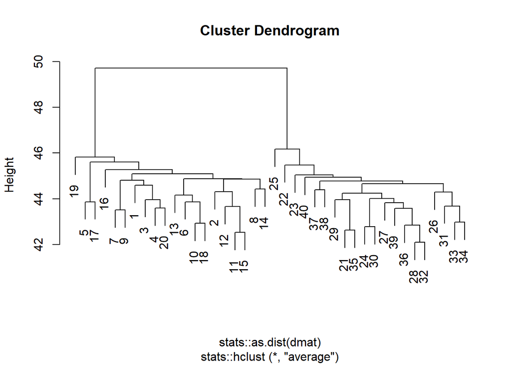

```r
hc_fit$fit %>% plot()
```

```r
grp = factor(rep(c(1, 0), each = 20))

regression <- function(y) {
  sum <- summary(lm(y ~ grp))
  pv <- sum$coefficients[2, 4]
  return(pv)
}


out <- tibble(gene = seq(1, nrow(Ch12Ex13)),
              p_values = unlist(purrr:: map(1:nrow(Ch12Ex13), ~regression(as.matrix(Ch12Ex13)[.x, ]))))
```

```r
out %>% arrange(p_values) %>% head(10)
```

```
# A tibble: 10 × 2
    gene p_values
   <int>    <dbl>
 1   502 1.43e-12
 2   589 3.19e-12
 3   600 9.81e-12
 4   590 6.28e-11
 5   565 1.74e-10
 6   551 1.10e- 9
 7   593 1.19e- 9
 8   584 1.65e- 9
 9   538 2.42e- 9
10   569 2.69e- 9
```

```r
# sig <- out %>% arrange(p_values) %>% filter(p_values < 0.05/nrow(Ch12Ex13))
sig <- out %>% arrange(p_values) %>% filter(p_values < 0.05 )
```

```r
# install.packages("pheatmap")
library(pheatmap)
# install.packages("ggplotify")
library(ggplotify) ## to convert pheatmap to ggplot2
# install.packages("heatmaply")
library(heatmaply) ## for constructing interactive heatmap
```

```r
#create data frame for annotations
dfh <- data.frame(sample=as.character(colnames(Ch12Ex13)), status = "disease") %>%
                column_to_rownames("sample")
dfh$status[seq(1, 20)] <-  "healthy"
dfh
```

```
      status
ID1  healthy
ID2  healthy
ID3  healthy
ID4  healthy
ID5  healthy
ID6  healthy
ID7  healthy
ID8  healthy
ID9  healthy
ID10 healthy
ID11 healthy
ID12 healthy
ID13 healthy
ID14 healthy
ID15 healthy
ID16 healthy
ID17 healthy
ID18 healthy
ID19 healthy
ID20 healthy
ID21 disease
ID22 disease
ID23 disease
ID24 disease
ID25 disease
ID26 disease
ID27 disease
ID28 disease
ID29 disease
ID30 disease
ID31 disease
ID32 disease
ID33 disease
ID34 disease
ID35 disease
ID36 disease
ID37 disease
ID38 disease
ID39 disease
ID40 disease
```

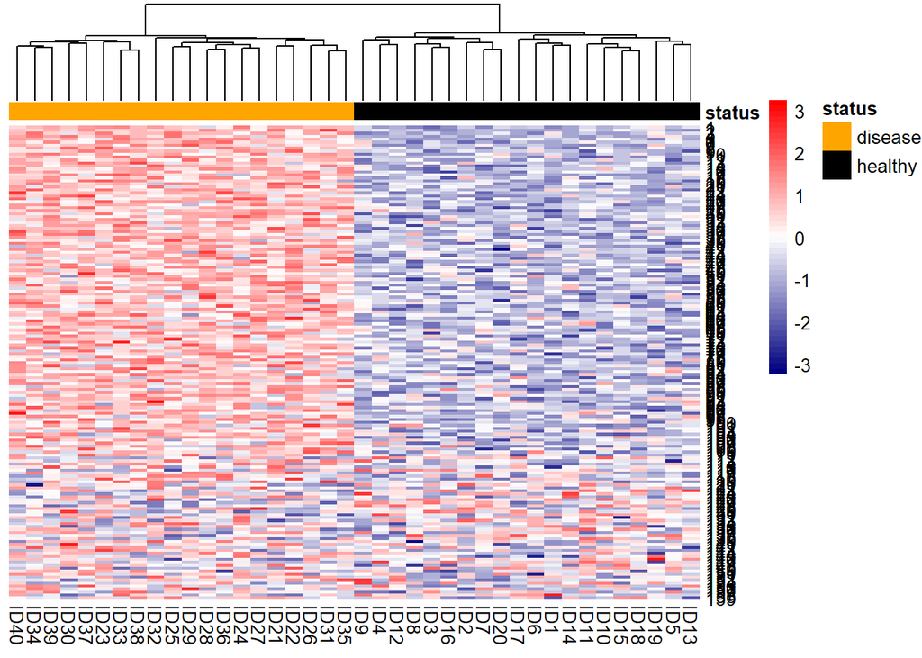

```r
pheatmap(Ch12Ex13[sig$gene, ],
         cluster_rows = FALSE,
         cluster_cols = T,
         scale = "row",
         annotation_col = dfh,
         annotation_colors = list(status = c(disease = "orange", healthy = "black")),
         color = colorRampPalette(c("navy", "white", "red"))(50))
```